# Tema6.1

jcantero

20/10/2020

Instala y carga el paquete MASS.

En el hay una tabla de datos llamada birthwt sobre factores que pueden incidir en el peso de los niños al nacer.

```r
library(MASS)
```

1. Utiliza str() y head() para explorar la estructura, y con help(), mirar el significado de cada variable.

```r
str(birthwt)
```

```
## 'data.frame':    189 obs. of  10 variables:
##  $ low  : int  0 0 0 0 0 0 0 0 0 0 ...
##  $ age  : int  19 33 20 21 18 21 22 17 29 26 ...
##  $ lwt  : int  182 155 105 108 107 124 118 103 123 113 ...
##  $ race : int  2 3 1 1 1 3 1 3 1 1 ...
##  $ smoke: int  0 0 1 1 1 0 0 0 1 1 ...
##  $ ptl  : int  0 0 0 0 0 0 0 0 0 0 ...
##  $ ht   : int  0 0 0 0 0 0 0 0 0 0 ...
##  $ ui   : int  1 0 0 1 1 0 0 0 0 0 ...
##  $ ftv  : int  0 3 1 2 0 0 1 1 1 0 ...
##  $ bwt  : int  2523 2551 2557 2594 2600 2622 2637 2637 2663 2665 ...
```

```r
head(birthwt)
```

```
##    low age lwt race smoke ptl ht ui ftv  bwt
## 85   0  19 182    2     0   0  0  1   0 2523
## 86   0  33 155    3     0   0  0  0   3 2551
## 87   0  20 105    1     1   0  0  0   1 2557
## 88   0  21 108    1     1   0  0  1   2 2594
## 89   0  18 107    1     1   0  0  1   0 2600
## 91   0  21 124    3     0   0  0  0   0 2622
```

```r
help("birthwt")
```

```
## starting httpd help server ... done
```

2. Calcula una tabla de frecuencias relativas marginales de los pares (raza de la madre, peso inferior a 2.5 kg o no) que permita ver si la raza de la madre influye en el peso del bebé.

```r
func_bwt <- function(x) {
  ret = ""
  if (x > 2500) {
    ret = ">2500"
  } else {
    ret = "<=2500"
  }

  return(ret)
}
btw = sapply(birthwt$bwt, func_bwt)
fa2 = table(birthwt$race, btw)

dimnames(fa2) = list(
  Raza = c("Blanca", "Color", "Otros"),
  Peso = c("<= 2.5 KG", "> 2.5 KG")
)
fa2
```

```
##         Peso
## Raza     <= 2.5 KG > 2.5 KG
##   Blanca        23       73
##   Color         11       15
##   Otros         25       42
```

3. Dibuja un diagrama de mosaico de la tabla del ejercicio anterior.

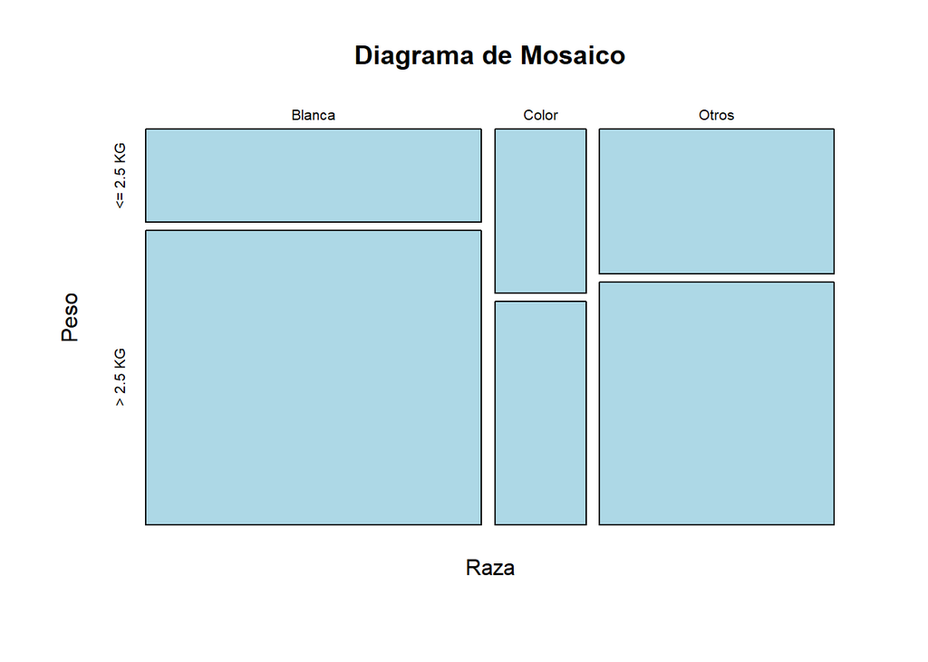

```r
plot(fa2, col = c("lightblue"), main = "Diagrama de Mosaico")
```

4. Dibuja un diagrama bidimensional de barras, con las barras organizadas en bloques, que permita visualizar la información de los ejercicios anteriores. Aprovecha para nombres adecuados a los bloques, colores a las barras, y añadir una leyenda que explique qué representa cada barra.

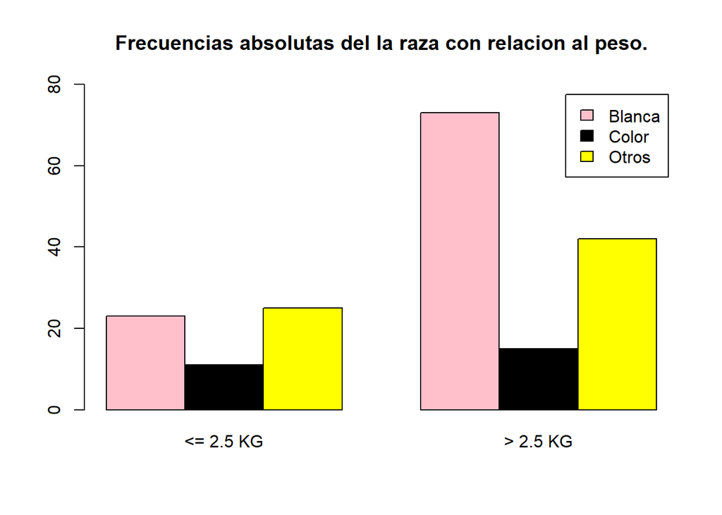

```r
barplot(fa2, beside = TRUE,
        legend.text = TRUE, ylim = c(0, 80),
        col = c("pink", "black", "yellow"),
        main = "Frecuencias absolutas del la raza con relacion al peso.")
```

5. ¿Se puede obtener alguna conclusión de la tabla y el diagrama de barras anterior? Argumenta tu respuesta Si las mujeres de raza blanca tiene hijos con mayor peso.
6. Repite los cuatro ejercicios anteriores para los pares (madre fumadora o no, peso inferior a 2.5 kg o no) y para los pares (madre hipertensa o no, peso inferior a 2.5 kg o no.

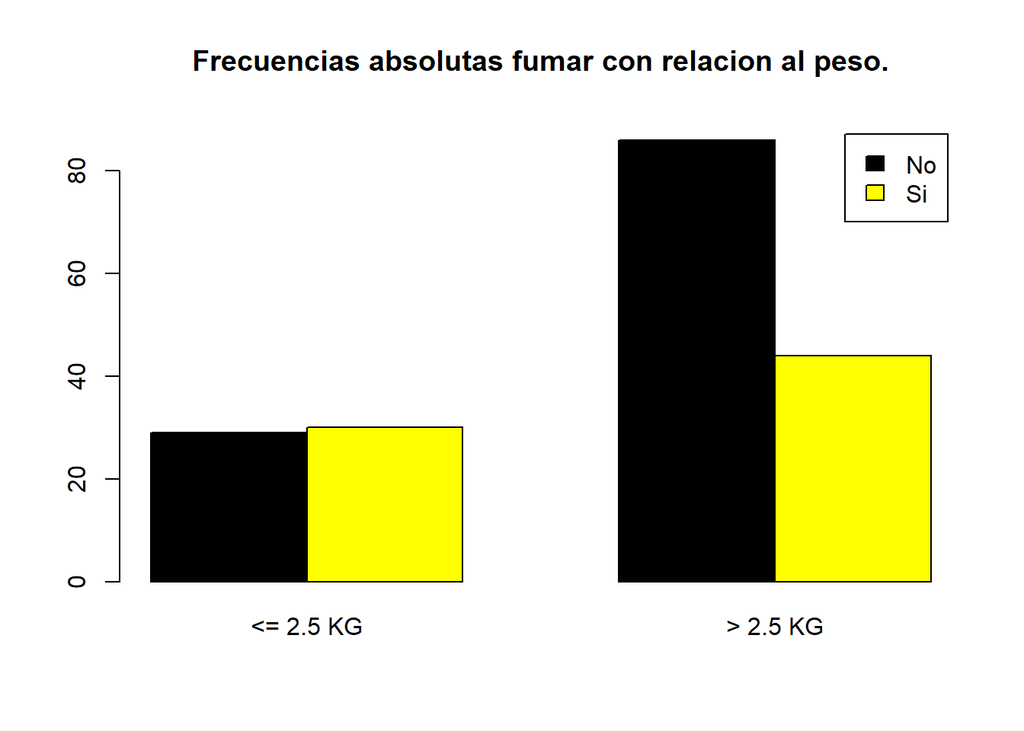

```r
func_binary <- function(x) {
  ret = ""
  if (x == 1) {
    ret = "Si"
  } else {
    ret = "No"
  }

  return(ret)
}

smoke = sapply(birthwt$smoke, func_binary)
fa3 = table(smoke, btw)
dimnames(fa3) = list(
  Fuma = c("No", "Si"),
  Peso = c("<= 2.5 KG", "> 2.5 KG")
)
barplot(fa3, beside = TRUE,
        legend.text = TRUE, ylim = c(0, 90),
        col = c("black", "yellow"),
        main = "Frecuencias absolutas fumar con relacion al peso.")
```